# Rendering LaTeX in R

The xdvir package provides functions for rendering LaTeX fragments as labels, annotations, and data symbols in R plots. There are convenient high-level functions for rendering LaTeX fragments, including labels on ggplot2 plots, plus lower-level functions for more fine control over the separate authoring, typesetting, and rendering steps. There is support for making use of LaTeX packages, including TikZ graphics. The rendered LaTeX output is fully integrated with R graphics output in the sense that LaTeX output can be positioned and sized relative to R graphics output and vice versa.

Paul Murrell https://www.stat.auckland.ac.nz/~paul/ (The University of Auckland)  
2025-07-16

## 1 Introduction

Text labels, titles, and annotations are essential components of any data visualization. Viewers focus a lot of their attention on text (Borkin et al. 2016), text is the most effective way to communicate some types of information (Hearst 2023), and the message obtained from a data visualization can be heavily influenced by the text on a plot (Kong et al. 2018).

R provides relatively flexible tools for adding text labels to plots. For example, in the `graphics` package, we can specify an overall plot title and axis titles via the `main`, `xlab`, and `ylab` arguments to the `plot()` function and we can add text at arbitrary locations on the plot with the `text()` and `mtext()` functions.

Unfortunately, these core tools for drawing text are quite limited in terms of the formatting of the text. For example, there is no facility for emphasizing an individual word using a **bold** or *italic* face within a text label.

The ggtext (Wilke and Wiernik 2022a) and gridtext (Wilke and Wiernik 2022b) packages greatly improved the situation by allowing text labels to include a small subset of markdown and HTML (plus CSS). This allowed, for example, changes in font face and color within text labels.

More recently, the marquee package (Pedersen and Mitáš 2024) improved the situation a great deal further by providing full support for markdown within text labels. This made it possible to layout more complex arrangements of text and even graphical content within text labels.

However, despite these advances, there are still some text formatting tasks that remain out of reach. For example, Figure 1 shows a plot with a text annotation in the top-right corner that contains a combination of features that cannot be produced using the available text-drawing tools.

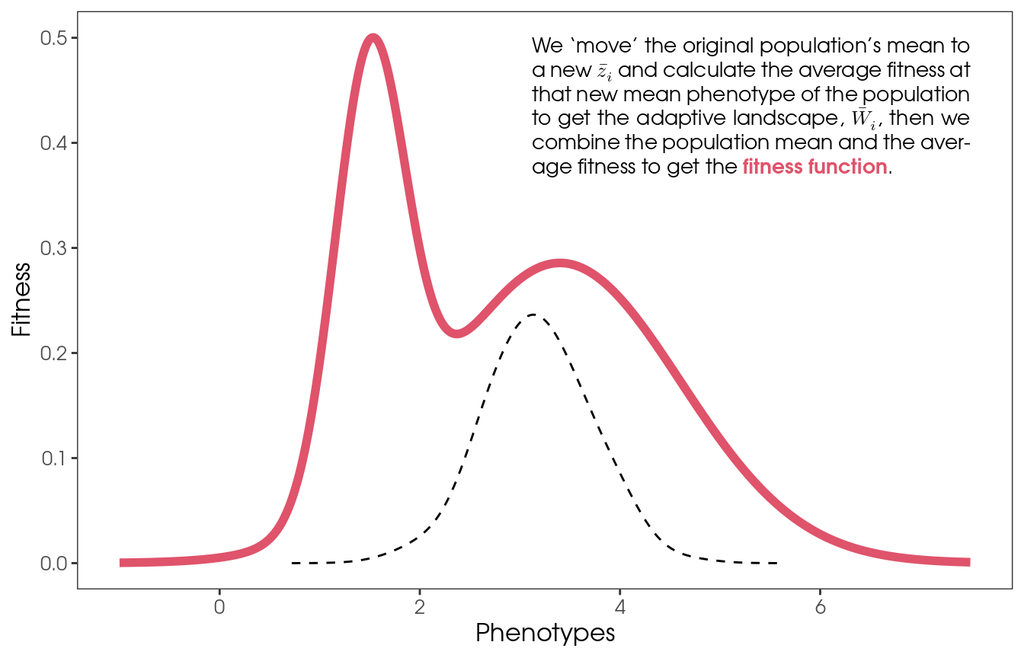

Figure 1: A plot with a text annotation in the top-right corner that contains several typesetting challenges: in-line mathematical expressions like $\bar z_i$; changes in color so that the last two words match the colour of the thicker line in the plot; and automated line-breaks with full justification and hyphenation.

The annotation in Figure 1 may not appear to be particularly special nor particularly complicated at first glance, but it harbors several important details:

- The text is a mixture of plain text and mathematical expressions (like $\bar{z}_i$). Furthermore, the mathematical expressions use a different font (Latin Modern) than the plain text (TeX Gyre Adventor) and the mixture is broken across multiple lines.

  The R graphics system can draw mathematical expressions (Murrell and Ihaka 2000) and that includes a mixture of plain text and mathematical expressions. Furthermore, the R graphics system uses a separate symbol font for mathematical expressions compared to plain text. However, further changes in font within the plain text is not possible and line breaks are not supported. There is also the problem that the typesetting of mathematical expressions in R graphics is not of a very high quality.
- The text is not all the same color; the final two words (but not the full stop) are red. Furthermore, the final two words are **bold**; they have a different font face compared to the rest of the text.

  The R graphics system can only draw a character value with a single color and a single font face. The gridtext and ggtext packages make it possible to change color within a character value, but they do not allow a mixture of character values and R mathematical expressions. Furthermore, they do not provide support for MathML `<math>` tags.
- The text is broken over multiple lines. Furthermore, the text is fully justified (not ragged-left or ragged-right justified) and one word has been split across lines and hyphenated. Although it is not obvious from the plot itself, the line breaks were also automatically generated to fit the text into a fixed width.

  The R graphics system can draw a character value across multiple lines, but only if explicit newlines are embedded in the character value (i.e., the line breaks are manual). The base function `strwrap()` can be used to break lines, but it is only designed for monospaced terminal output and ragged-right justification. The gridtext and ggtext packages can calculate simple automated line breaks, but they will not break a word across lines (or hyphenate) and they cannot fully justify the resulting text. The marquee package can automate line breaks and fully justify text, but it cannot hyphenate nor can it produce mathematical expressions.

The features outlined above are all examples of *typesetting*; determining an arrangement of individual characters and symbols (glyphs) that could be as simple as placing one character after another (from left to right), but could also be as complex as arranging mathematical symbols, splitting text into multiple columns, or writing text vertically from top to bottom.

From R 4.3.0, it has been possible to draw text from a set of typeset glyphs using the functions `grDevices::glyphInfo()` and `grid::grid.glyph()` (Murrell et al. 2023). This facility offers the promise of being able to render arbitrary typeset text in R. However, it presupposes that we are able to generate a set of typeset glyphs.

The marquee package provides an example of a package that can generate typeset glyphs. It is capable of converting markdown input into a set of glyphs and their positions, which are then rendered in R.

This article describes the `xdvir` package, which is another example of a package that can generate typeset glyphs. In this case, the input is LaTeX, a TeX engine processes the LaTeX source to create DVI output, which is essentially a set of glyphs and their positions, and then `xdvir` reads the DVI output and renders the result in R.[^1] The benefit of the `xdvir` package is that it provides access to the typesetting capabilities of LaTeX, which includes hyphenation, fully justified text, mixtures of plain text and mathematical expressions—all of the features demonstrated in Figure 1—and much more.

The next section describes the basic usage of the `xdvir` package. This is followed by a section that breaks down the design of the `xdvir` package to show the steps that are required to render LaTeX output in R. Subsequent sections explore several of the complexities that can arise with rendering LaTeX text in R graphics and some of the solutions that the `xdvir` package provides. The article ends with several extended examples of rendering LaTeX text in R.

## 2 LaTeX text labels in R

The simplest way to draw LaTeX text with the `xdvir` package is to call the `grid.latex()` function. The first argument to this function is a character value, which is interpreted as a fragment of LaTeX code. For example, the following code draws a text label that contains a subset of the larger annotation from Figure 1. We use just a subset here in order to keep the code readable.

Because LaTeX code tends to contain a large number of backslashes, the code below uses the `r"(...)"` syntax for raw character constants, so that we do not have to escape each backslash with a double backslash. The resulting image is shown below the code. Although it is not immediately obvious from that image, the text, or rather the glyphs, in the image are rendered by R.

```r
library(xdvir)
```

```r
simpleTeX <- r"(We move the original mean to $\bar z_i$)"
```

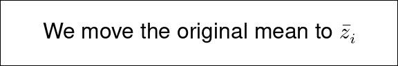

```r
grid.latex(simpleTeX)
```

It is possible to produce something similar to this result using the *plotmath* feature in R, as shown in the following code (and the image below the code). However, this demonstrates that one advantage of using `xdvir`, even for a simple piece of text like this, is the superior quality of the LaTeX fonts and typesetting for mathematical expressions.

```r
plotmath <- expression("We move the original mean to "*bar(italic(z))[i])
```

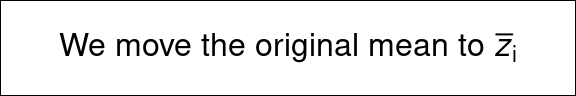

```r
grid.text(plotmath)
```

Another immediate benefit of `xdvir` is that we can automatically fit the text within a specified width. For example, the following code draws the LaTeX fragment `tex` again, but this time forces it to fit within a column that is half the width of the image.

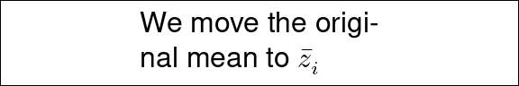

```r
grid.latex(simpleTeX, width=.5)
```

As the function name `grid.latex()` suggests, that function produces low-level drawing in the `grid` package graphics system. The text is just drawn relative to the current `grid` viewport, wherever that may be on the page. While this is extremely flexible, it is more likely that we want to combine and coordinate the text with a high-level plot of some sort, like the annotation in Figure 1. There are various ways that low-level `grid` drawing can be combined with a high-level plot, but we will leave those demonstrations to later sections.

Instead, for now, we will demonstrate a more common scenario: drawing LaTeX text labels on a ggplot2 plot (Wickham 2016). For this purpose, the `xdvir` package provides the `element_latex()` function. This allows us to specify a LaTeX fragment as a plot label and then we can indicate the special nature of the label via the `ggplot2::theme()` function.

For example, the following code uses the same LaTeX fragment from the example above as the title of a ggplot2 plot. The resulting plot is shown in Figure 2. One detail about this result is that the text in this title is larger than the text drawn by the call to `grid.latex()` above, even though exactly the same TeX fragment is being drawn. A closer inspection reveals that the font is also different. These differences reflect the fact that `grid.latex()` and `element_latex()` respect the graphical parameter settings—font families and font sizes—that are in effect when the LaTeX fragment is drawn. In Figure 2 that means respecting the theme settings of the ggplot2 plot. The `ggIntro` object in the code below contains a description of the main ggplot2 plot from Figure 1. The code for generating `ggIntro` is not shown in order to keep the code below readable, but it is available in the supplementary materials for this article.

```r
library(ggplot2)
```

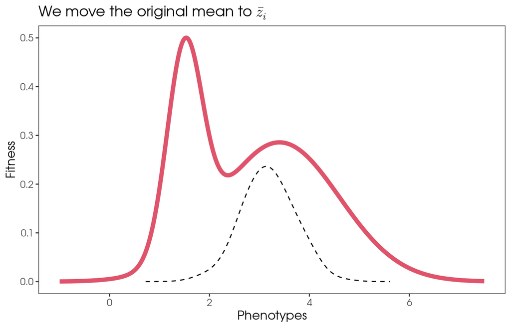

Figure 2: The `ggplot2` plot from Figure 1, without the text annotation, but with a title that was specified using a LaTeX fragment and the function `element_latex()`.

```r
ggIntro +
    labs(title=simpleTeX) +
    theme(plot.title=element_latex())
```

The `xdvir` package also provides a `geom_latex()` function for drawing text labels, similar to the standard `ggplot2::geom_text()` function. The values specified for the `label` aesthetic for `geom_latex()` are treated as fragments of LaTeX code. For example, Figure 3 shows a plot with a set of red points and a set of red labels, one for each point. The points are drawn using the standard `ggplot::geom_point()` function, but the labels are drawn using `geom_latex()` from the `xdvir` package. The red labels for the red points in Figure 3 are small LaTeX fragments that each describe a simple LaTeX mathematical expression. The data set used for the red points and labels is stored in a data frame called `means` and the LaTeX fragments are in a column called `label`, as shown below.

```r
means$label
```

```
[1] "$\\bar x_1$" "$\\bar x_2$" "$\\bar x_3$" "$\\bar x_4$"
[5] "$\\bar x_5$"
```

The following code draws the plot in Figure 3. A call to `ggplot2::geom_point()` draws the red points and a call to `geom_latex()` draws the red labels. The `ggGeom` object in the code below describes the main plot, which consists of gray dots, horizontal and vertical lines, and y-axis labels. The code for generating `ggGeom` is not shown in order to keep the code below readable, but it is available in the supplementary materials for this article.

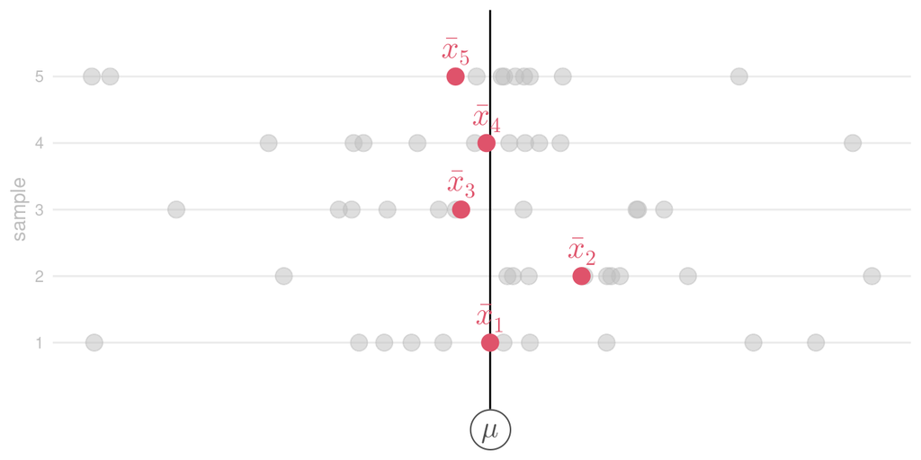

Figure 3: A `ggplot2` plot with text labels specified as LaTeX fragments and drawn using the `geom_latex()` function.

```r
ggGeom +
    geom_point(aes(x, sample), data=means, colour=2, size=4) +
    geom_latex(aes(x, sample, label=label), data=means,
               size=6, vjust=-.4, colour=2)
```

## 3 Under the hood

The previous section showed that simple usage of the `xdvir` package only requires specifying a LaTeX fragment as the text to draw. For example, several examples used the LaTeX fragment shown below.

```r
simpleTeX
```

```
[1] "We move the original mean to $\\bar z_i$"
```

The `grid.latex()` function has three tasks to perform in order to draw that LaTeX fragment in R:

**Authoring:**

The LaTeX fragment has to be turned into a complete LaTeX document.

The `author()` function in the `xdvir` package allows us to perform this step separately. For example, the following code takes the LaTeX fragment `simpleTeX` and produces a complete LaTeX document, `simpleDoc`, that is ready to typeset.

```r
simpleDoc <- author(simpleTeX)
```

```r
simpleDoc
```

```
%% R package xdvir_0.1.3; engine name: XeTeX; engine version: XeTeX 3.141592653-2.6-
\documentclass[varwidth]{standalone}
\usepackage{unicode-math}
\begin{document}
We move the original mean to $\bar z_i$
\end{document}
```

**Typesetting:**

The LaTeX document has to be typeset to produce a set of glyphs and their positions.

The `typeset()` function in the `xdvir` package allows us to perform this step separately. For example, the following code takes the LaTeX document `simpleDoc` and produces a `"DVI"` object, `simpleDVI`, that contains instructions specifying the fonts to use (lines that contain `x_fnt_def` and `fnt_num` in the output below), the glyphs to use from those fonts (lines that contain `x_glyph` in the output below), and where to draw those glyphs (lines that contain `down` and `right` and `x_glyph`). The output shown below has been trimmed to save space and to make it easier to read.

```r
simpleDVI <- typeset(simpleDoc)
simpleDVI
```

```
pre          version=7, num=25400000, den=473628672, mag=1000,
             comment=R package xdvir_0.1.3; engine name: XeTeX; engine version: XeTe
bop          counters=1 0 0 0 0 0 0 0 0 0, p=-1
xxx1         k=47
             x=pdf:pagesize width 143.26802pt height 9.48027pt
down3        a=-4736287

...

right3       b=-4736287
x_fnt_def    fontnum=28, ptsize=655360
             fontname=/usr/share/texmf/fonts/opentype/public/lm/lmroman10-regular.ot
fnt_num_28
x_glyph      id=113, x=0, y=0
x_glyph      id=50, x=619315, y=0
w3           b=218235
x_glyph      id=75, x=0, y=0

...
```

**Rendering:**

The result of the typesetting step has to be drawn in R.

The `render()` function in the `xdvir` package allows us to perform this step separately. For example, the code below renders the typesetting information from the `simpleDVI` object in R. The resulting image is shown below the code.

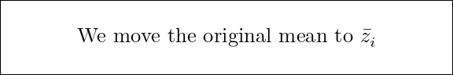

```r
render(simpleDVI)
```

One detail about the output above is that the rendered text from this `render()` call is smaller and in a different font compared to the example from the previous section, which was produced by a `grid.latex()` call. This reflects the fact that `grid.latex()`, in the authoring step, respects the font family and font size that are in effect when the text is rendered. By contrast, the `render()` call is drawing typeset information from a LaTeX document that just makes use of the default LaTeX font, Computer Modern (or to be more precise, a modernized version called Latin Modern) at 10pt.

## 4 LaTeX packages

The code examples so far have dealt with relatively simple fragments of LaTeX code that consist of just text plus some simple mathematical expressions. While this is already useful, it barely scratches the surface of what is possible with LaTeX code.

Many additional effects can be obtained with LaTeX code by loading LaTeX packages. As a simple example, changing the color of text requires loading the LaTeX package `xcolor`. These LaTeX packages can be loaded using the `packages` argument of the `grid.latex()` function (or the `element_latex()` function or the `geom_latex()` function). For example, the following code draws text with the last two words in red.

```r
colourTeX <- r"(We combine to get the \textcolor{red}{Fitness Function})"
```

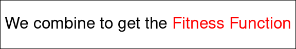

```r
grid.latex(colourTeX, packages="xcolor")
```

The argument `packages="xcolor"` is used in the authoring step to load the package in the LaTeX document preamble. This is demonstrated below with an explicit call to the `author()` function. We can see that `\usepackage{xcolor}` has been added to the LaTeX document.

```r
colourDoc <- author(colourTeX, packages="xcolor")
```

```r
colourDoc
```

```
%% R package xdvir_0.1.3; engine name: XeTeX; engine version: XeTeX 3.141592653-2.6-
\documentclass[varwidth]{standalone}
\usepackage{unicode-math}
\usepackage{xcolor}
\begin{document}
We combine to get the \textcolor{red}{Fitness Function}
\end{document}
```

This in turn affects the typesetting step: without the `xcolor` package, the LaTeX command `\textcolor` would not be recognized; with the `xcolor` package, the `\textcolor` command produces instructions to change color in the `"DVI"` output. This is demonstrated below with an explicit call to the `typeset()` function. An example of the color-change instructions is the line containing `color push` in the output below the code.

```r
colourDVI <- typeset(colourDoc)
colourDVI
```

```
pre          version=7, num=25400000, den=473628672, mag=1000,
             comment=R package xdvir_0.1.3; engine name: XeTeX; engine version: XeTe
bop          counters=1 0 0 0 0 0 0 0 0 0, p=-1

...

x_fnt_def    fontnum=28, ptsize=655360
             fontname=/usr/share/texmf/fonts/opentype/public/lm/lmroman10-regular.ot
fnt_num_28
x_glyph      id=113, x=0, y=0
x_glyph      id=50, x=619315, y=0

...

xxx1         k=20
             x=color push rgb 1 0 0
x_glyph      id=54, x=0, y=0
x_glyph      id=66, x=427950, y=0

...
```

The argument `packages="xcolor"` is also used in the rendering step because, without it, the rendering would not take any notice of the instructions to change color. This is demonstrated below with an explicit call to the `render()` function. The resulting image differs from the previous one because it uses the default LaTeX font, but we can see the same change in color for the last two words.

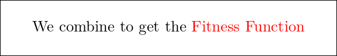

```r
render(colourDVI, packages="xcolor")
```

There are several LaTeX packages with predefined support in the `xdvir` package, including `xcolor` for changes in color and `fontspec` for changes in font. Support can be added for other LaTeX packages with the `LaTeXpackage()` function. We will see other predefined packages and an example of defining a new LaTeX package in later sections.

## 5 Justifying text

By default, the LaTeX text drawn by `grid.latex()` is centered upon a specified location. For example, the following code draws the `simpleTeX` fragment vertically centered at a location half-way up the image (as indicated by the gray line).

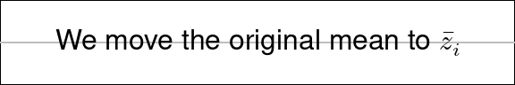

```r
grid.latex(simpleTeX, y=.5)
```

We can specify a different justification using the `vjust` argument. For example, the following code draws the same `simpleTeX` fragment at the same location, but with a bottom-justification. Notice that the bottom of the text is based on the bounding box of the text, so the bottom of the text is the bottom of the subscript “i”.

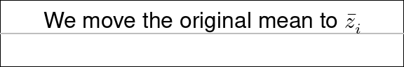

```r
grid.latex(simpleTeX, y=.5, vjust="bottom")
```

In some situations it will be much more useful to justify text relative to the text baseline, as shown by the following code.

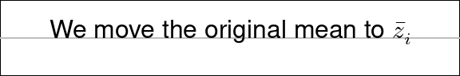

```r
grid.latex(simpleTeX, y=.5, vjust="baseline")
```

The `xdvir` package has a very simple algorithm for determining the text baseline, but there is also predefined support for the LaTeX package `preview`, which produces a more reliable baseline. That baseline can be accessed, assuming the `preview` package is loaded, by specifying `vjust="preview-baseline"`.

There is also an `hjust` argument for horizontal justification. This accepts the standard values, `"left"`, `"centre"`, and `"right"`, but also accepts `"bbleft"`, `"bbcentre"`, and `"bbright"`. The latter three are based on a bounding box around the actual ink that is drawn, which does not include space before or after glyphs (left-side bearing and right-side bearing). The following code provides a demonstration of the difference by drawing the simple LaTeX fragment from previous examples as the title of a ggplot2 plot. We add a (mathematical) vertical bar to the end of the LaTeX fragment and draw the title larger than normal and justify the text against the right side of the plot region, using `"right"` justification first and then using `"bbright"` justification. The output below the code just shows the very top of the plot in order to save space.

```r
rightBearingTeX <- paste0(simpleTeX, "$|$")
```

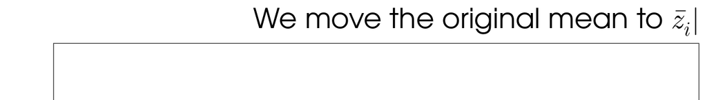

```r
ggIntro +
    labs(title=rightBearingTeX) +
    theme(plot.title=element_latex(size=20, hjust="right"))
```

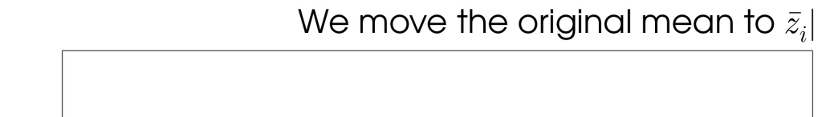

```r
ggIntro +
    labs(title=rightBearingTeX) +
    theme(plot.title=element_latex(size=20, hjust="bbright"))
```

The difference between the two plots is that the second vertical bar is precisely aligned with the right edge of the plot region whereas the first vertical bar is slightly to the left of the right edge of the plot region (because of the right-side bearing of the vertical bar glyph). This is a very small detail, but it is something that can be visually jarring if we are trying to align components of a plot in order to produce a clean design. This fine level of control is exactly the sort of precision that we are seeking by working with LaTeX typesetting.

## 6 Integrating text

Justifying LaTeX text is a simple example of a larger problem: *integrating* LaTeX text. For example, the text annotation in Figure 1 is integrated with the plot in the sense that it is positioned relative to the plot region. In fact, closer inspection reveals that the text annotation is carefully top-justified with the maximum y-value of the red line and right-justified with the maximum x-value of the red line.

Put in terms of *integration* rather than justification, the text annotation in Figure 1 is integrated with the plot because the LaTeX text is drawn at a location that is coordinated with the location of other R graphics drawing in the plot.

Another example of integration, that reverses the roles, is coordinating other R graphics drawing with the location of LaTeX text. The following code provides a simple example. The LaTeX fragment is the simple one from previous examples with two additions: there are `\zsavepos` commands to mark specific locations within the text and associate them with labels (`"a"` and `"b"`); and there are `\Rzmark` commands to export those locations for R to see.

```r
zrefTeX <- r"(We move the original\zsavepos{a} mean to \zsavepos{b}$\bar z_i$
\Rzmark{a}\Rzmark{b})"
```

If we render this LaTeX fragment, we just get the familiar output. The commands that we added to the LaTeX fragment are based on the LaTeX package `zref`, so we must load that package.

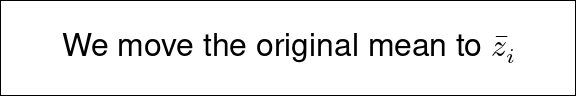

```r
grid.latex(zrefTeX, packages="zref")
```

However, we can now access the special locations in the LaTeX output using the `getMark()` function from the `xdvir` package. For example, the following code accesses location `"a"`, which is just after the word “original”, and draws a small red dot at that location.

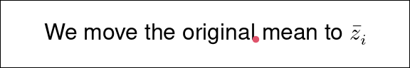

```r
a <- getMark("a")
grid.circle(a$devx, a$devy, r=unit(.5, "mm"), gp=gpar(col=2, fill=2))
```

The following code accesses location `"b"`, which is just before the letter “z”, and draws a curved arrow from `"a"` to `"b"`.

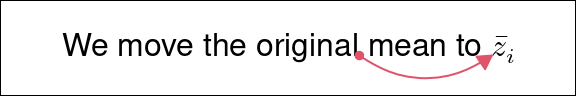

```r
b <- getMark("b")
grid.xspline(unit.c(a$devx, .5*(a$devx + b$devx), b$devx),
             unit.c(a$devy, a$devy - unit(3, "mm"), a$devy),
             shape=-1, gp=gpar(col=2, fill=2),
             arrow=arrow(length=unit(2, "mm"), type="closed"))
```

The exported locations also produce “anchors” that we can use to justify LaTeX text. For example, the following code draws the simple LaTeX fragment with position `"a"` at the center of the image (which is indicated by gray lines).

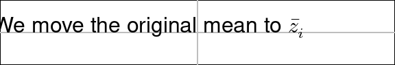

```r
grid.latex(zrefTeX, packages="zref", hjust="a", vjust="a")
```

Figure 4 provides a more realistic demonstration. This figure shows the plot from Figure 1 with a line added to visually connect the thick red line with the red part of the LaTeX annotation. The code for this plot is not shown for reasons of space, but it makes use of the same basic idea as the code above by saving locations within the LaTeX output and then accessing them with the `getMark()` function. The full code is available in the supplementary materials for this article.

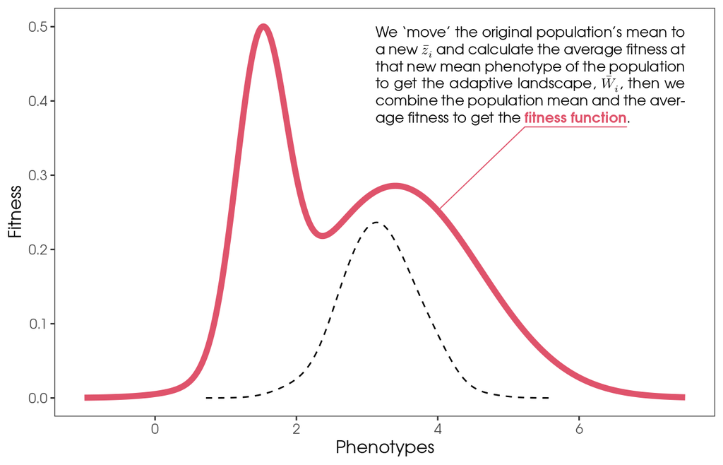

Figure 4: The `ggplot2` plot from Figure 1, including the LaTeX annotation, with a line added relative to marked locations within the LaTeX annotation (and relative to the thick red line).

## 7 LaTeX graphics

The examples so far have demonstrated using LaTeX code to describe text labels, combined with using R to draw general graphics—lines and circles and so on. It is also possible to use LaTeX to draw general graphics. In particular, the LaTeX package TikZ provides very powerful and flexible graphics facilities. The `xdvir` package provides support for the LaTeX package TikZ, so we are able to render TikZ graphics in R.

For example, the following LaTeX code describes a TikZ picture consisting of two text labels enclosed within circles, with arrows connecting the circles.

```r
tikzTeX <- r"(%
\path (0, 0) node[circle,minimum size=.5in,draw,thick] (x) {\sffamily{R}}
       (3, 0) node[circle,minimum size=.5in,draw,thick] (y) {Ti\textit{k}Z!};
\draw[-{stealth},thick] (x) .. controls (1, 1) and (2, 1).. (y);
\draw[-{stealth},thick] (y) .. controls (2, -1) and (1, -1) .. (x);)"
```

The following code draws this TikZ picture in R. The argument `packages="tikzPicture"` is necessary to ensure that the TikZ package is loaded in the authoring step, that TikZ output is produced in the typesetting step, and that R takes notice of the TikZ output in the rendering step.

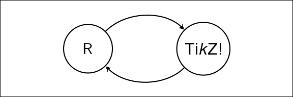

```r
grid.latex(tikzTeX, packages="tikzPicture")
```

The label on the x-axis of Figure 3 is another simple TikZ picture that uses TikZ commands to draw the Greek letter mu within a circle. This example is not completely trivial because it uses the LaTeX concept of “phantom” text to make the circle large enough to fit a capital “M” even though no such character is drawn. This is another example of the detailed typsetting capabilities that access to LaTeX provides.

```r
muDot <- r"(%
\begin{tikzpicture}
\node[draw,circle,thick,inner sep=0.5mm]{\vphantom{M}$\mu$};
\end{tikzpicture})"
```

The LaTeX code this time includes an explicit `\begin{tikzpicture}` and `\end{tikzpicture}`. Those commands were implicitly added in the previous example because we specified `packages="tikzPicture"`. This time, we have explicitly provided the commands, so we just specify `packages="tikz"`.

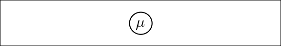

```r
grid.latex(muDot, packages="tikz")
```

We will see a more complex example of TikZ output in a later section. Figure 5 is also a TikZ picture that has been rendered in R.

## 8 Programmatic generation of LaTeX

One obstacle to adopting the `xdvir` package is that it assumes that the user knows how to create a LaTeX fragment (i.e., write LaTeX code). While the `xdvir` package provides some assistance so that the user is only required to write a LaTeX fragment rather than a complete LaTeX document, LaTeX fragments for text labels tend to be more complex than plain text labels, thanks to the additional markup that is required.

However, LaTeX code is still just text. This means that all of the text-generating tools in R are available to help with authoring LaTeX fragments. For example, the labels used to render text data symbols in Figure 3 could be generated via a simple call to the `paste0()` function, as shown below.

```r
paste0("$\\bar x_", 1:5, "$")
```

```
[1] "$\\bar x_1$" "$\\bar x_2$" "$\\bar x_3$" "$\\bar x_4$"
[5] "$\\bar x_5$"
```

There are also packages that can generate larger fragments of LaTeX code. For example, there are packages like xtable (Dahl et al. 2019) and latexpdf (Bergsma 2023) for generating LaTeX tables and the rmarkdown package (Xie et al. 2018) can generate LaTeX documents from Markdown input. The Literate Programming section of the [Reproducible Research CRAN Task View](https://cran.r-project.org/web/views/ReproducibleResearch.html) provides a more comprehensive list of relevant R packages. The texPreview package (Sidi and Polhamus 2024) may also be helpful for previewing the output of LaTeX code within an R session.

Some of these tools can be particularly useful for generating larger chunks of LaTeX code, although the LaTeX code that is produced may consist of entire documents rather than just LaTeX fragments. The next section describes how we can cope with that situation.

## 9 Customization and debugging

Most of the examples in this article take a fragment of LaTeX code and pass it to the `grid.latex()` function, which performs an authoring step, a typesetting step, and a rendering step. We saw in a previous section that there are functions `author()`, `typeset()`, and `render()` that allow us to perform these steps separately (see Figure 5). This provides more control over the individual steps and allows us to inspect the results of the individual steps, which can be useful for debugging. In this section, we explore further options for controlling the authoring, typesetting, and rendering steps.

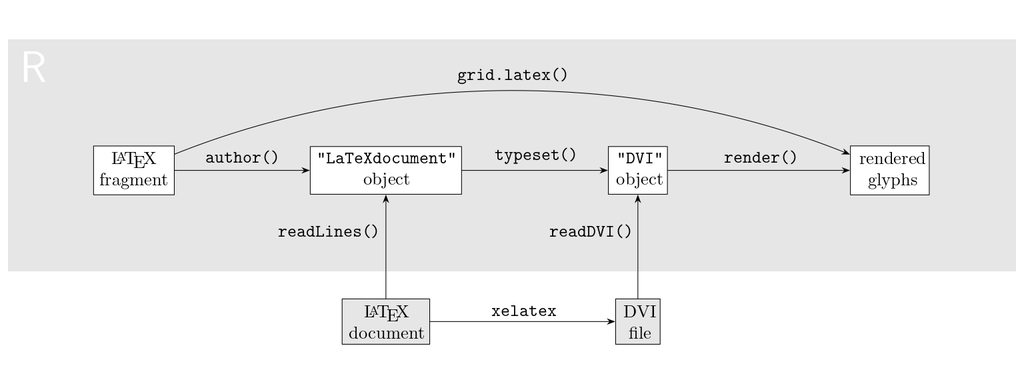

Figure 5: The design of the `xdvir` package.

The `author()` function transforms a LaTeX fragment into a complete LaTeX document. Although there are arguments to the `author()` function that allow some control over that transformation, e.g., the `packages` argument, it does not allow full control over the composition of the LaTeX document. Fortunately, a LaTeX document within R is essentially just a character vector, so another way to author a LaTeX document is to create an external text file and read that into R. This allows complete control over the content of the LaTeX document. Another possibility is that we want to use a LaTeX document that we did not create, for example, if we write Markdown code and convert it to LaTeX code.

The `typeset()` function transforms a LaTeX document into a `"DVI"` object that contains a set of typeset glyphs. There is limited control over this process as well, with only the `engine` argument allowing us to select between `"xetex"` or `"luatex"`. Again, one way to obtain greater control is to perform this step outside of R by running a TeX engine, e.g., `xelatex`, on an external text file to produce a DVI file. The `xdvir` package provides the `readDVI()` function to read external DVI files into R and these can then be passed to the `render()` function for drawing.

One important caveat is that both a `"LaTeXdocument"` object that is produced by the `author()` function and a `"DVI"` object that is produced by the `typeset()` function contain information about how they were created, for example, the TeX `engine` that was specified and the LaTeX packages that were loaded. The `typeset()` function checks this information and warns if we ask to typeset a `"LaTeXdocument"` that was produced for a different TeX engine. Similarly, the `render()` function, which also has an `engine` argument, checks and warns if we ask to render a `"DVI"` object that was produced using a different TeX engine.

External LaTeX documents and DVI files do not (explicitly) contain this information so it is up to the user to ensure that the TeX engine, and any LaTeX packages, are consistent with the arguments provided to the functions `typeset()` and `render()`. In some situations, even with the appropriate level of care, it will be impossible to avoid warnings.

## 10 Example 1

This section demonstrates a more complete example of rendering LaTeX text within a plot. The plot, shown in Figure 6, provides a clear example of the more advanced typesetting capabilities of LaTeX; the text annotation in the top-left corner of the plot is not only typeset into two columns, but both columns are fully justified and feature several examples of hyphenation.

This example also demonstrates one way to integrate a `grid.latex()` call with a plot that was drawn using functions from the `graphics` package. We will also see a simple demonstration of the `LaTeXpackage()` function to allow use of a LaTeX package that has no predefined support in `xdvir`.

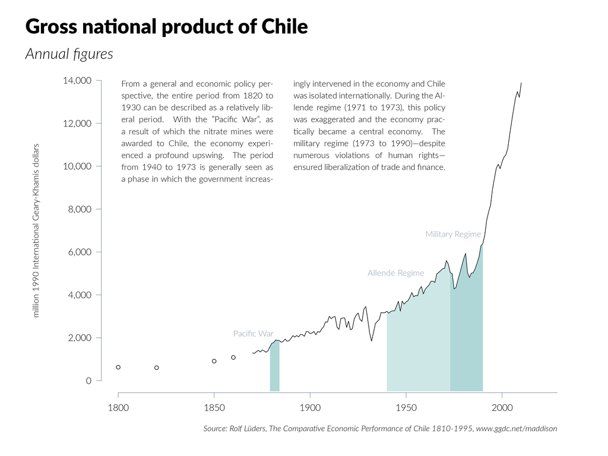

Figure 6: A plot with a two-column text annotation. This plot is an adaptation of Figure 4.1 from Thomas Rahlf’s book “Data Visualisation with R” (Rahlf 2017).

The details of the code that produces the main plot—everything except the two columns of text in the top-left corner—are not relevant to this article so we perform this drawing just with a call to a `rahlfPlot()` function that is defined in the supplementary material for the article. The result is shown in Figure 7.

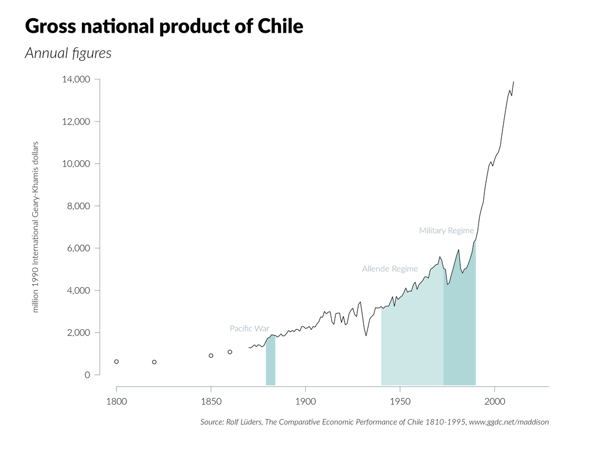

Figure 7: The main plot from Figure 6 without the two columns of text annotation. This plot is drawn using functions from the `graphics` package.

```r
rahlfPlot()
```

Because the main plot is drawn using functions from the `graphics` package, in order to integrate the output from `grid.latex()` with the plot, we need to convert the plot to an equivalent drawing that uses functions from the `grid` package. This can be achieved with the `grid.echo()` function from the gridGraphics package (Murrell and Wen 2020), as shown below.

```r
library(gridGraphics)
grid.echo()
```

We want to integrate the LaTeX text with the main plot. In particular, we want the top of the text to be aligned with the value 14,000 on the y-scale of the plot. There is also a 1cm gap between the left of the text and the y-axis line. In order to achieve this, we can navigate to the `grid` viewport that corresponds to the main plot region, which also has scales that match the plot scales. The naming scheme for the `grid` viewports that `grid.echo()` generates is described in Murrell (2015).

```r
downViewport("graphics-window-1-1")
```

We are now ready to render the LaTeX text within the plot. The LaTeX code for this example is shown below. This is a larger LaTeX fragment than we have previously seen, but more importantly it contains a larger number of LaTeX commands to control the typesetting of the text. For example, we control the font family with a `\setmainfont` command, we control font size and vertical line spacing with a `\fontsize` command, we control the overall width of the text using a `minipage` environment, we set the number of columns using a `multicol` environment, and we control the horizontal spacing between columns with a `\setlength` command.

```
\setmainfont{Lato-Light}
\fontsize{12pt}{17pt}\selectfont
\setlength{\columnsep}{1cm}
\begin{minipage}[t]{16.25cm}
\begin{multicols}{2}
From a general and economic policy perspective, the entire period from
1820 to 1930 can be described as a relatively liberal period. With the
"Pacific War", as a result of which the nitrate mines were awarded to
Chile, the economy experienced a profound upswing. The period from
1940 to 1973 is generally seen as a phase in which the government
increasingly intervened in the economy and Chile was isolated
internationally. During the Allende regime (1971 to 1973), this policy
was exaggerated and the economy practically became a central
economy. The military regime (1973 to 1990)---despite numerous
violations of human rights---ensured liberalization of trade and
finance.
\end{multicols}
\end{minipage}
```

The `\setmainfont` and `\fontsize` commands in the LaTeX code require the LaTeX package `fontspec` to be loaded, but this is not a problem because there is predefined support for `fontspec` in the `xdvir` package. However, the `multicol` environment in the LaTeX code requires the LaTeX package `multicol` and there is no predefined support for that in `xdvir`. The following code uses the `LaTeXpackage()` function to provide support for the LaTeX package `multicol`. In a simple case like this, all we have to do is provide a name for the package (`"multicol"`) and use the `preamble` argument to provide the LaTeX code that should be added in the authoring step to load the LaTeX package. We also call the `registerPackage()` function so that we can refer to this LaTeX package just by its name.

```r
multicol <- LaTeXpackage("multicol",
                         preamble="\\usepackage{multicol}")
registerPackage(multicol)
```

Finally, we call `grid.latex()` to add the LaTeX text to the plot. The object `rahlfTeX` contains the LaTeX code, we specify the LaTeX packages that have to be loaded, including the `"multicol"` package that we just registered, and we position the text 1cm in from the left of the the plot viewport and at 14,000 on the y-axis. The final result is shown in Figure 6.

```r
grid.latex(rahlfTeX,
           packages=c("fontspec", "multicol"),
           x=unit(1, "cm"), y=unit(14000, "native"),
           hjust="left", vjust="top")
```

## 11 Example 2

This section looks at another more complete example of a plot with a LaTeX annotation (Figure 8). This example demonstrates the sophisticated effects that are possible by combining TikZ graphics with LaTeX typesetting, in this case to produce an annotated mathematical expression. This example also demonstrates a way to integrate lower-level `grid.latex()` output with a ggplot2 plot (rather than using `element_latex()` or `geom_latex()`).

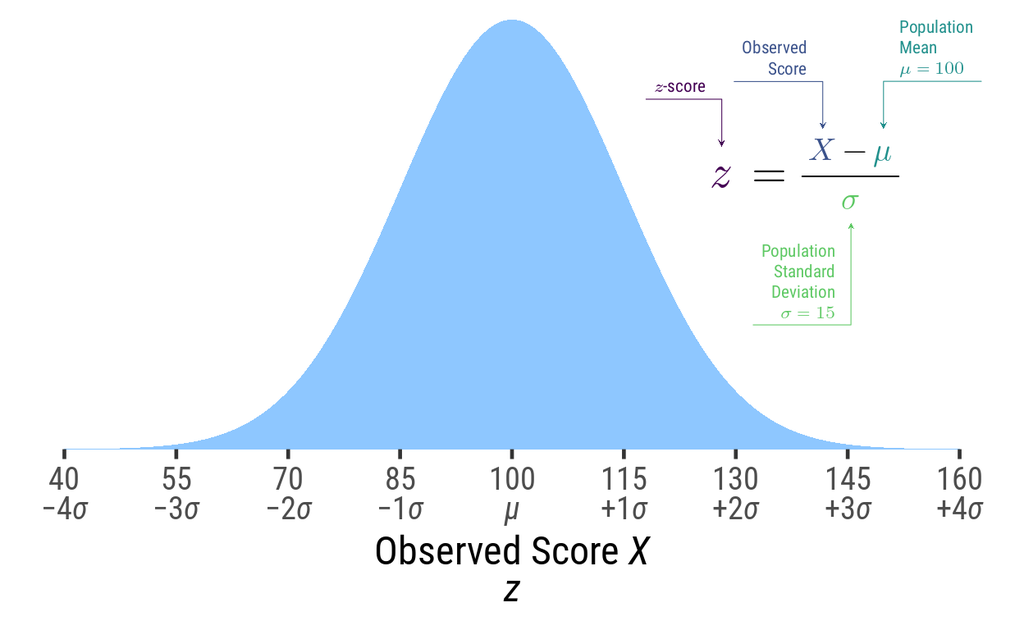

Figure 8: A plot with annotated mathematical expression. This plot is an adaptation of the plot in Schneider (2023).

The main plot in this example is a ggplot2 plot. The details of the code that generates the main plot are not particularly relevant to this article, so the main plot is described in the object `ggSchneider`, which is defined in the supplementary materials for the article. One point worth noting is that the labeling on the x-axis, which combines italic Greek letters with upright digits and signs, is produced using the ggtext package. In other words, this example combines two levels of text annotation: labels on the x-axis that are relatively simple, but still beyond the capabilities of core R text drawing; and much more sophisticated text annotations that require access to a complex system like LaTeX. The main plot produced by `ggSchneider` is shown in Figure 9.

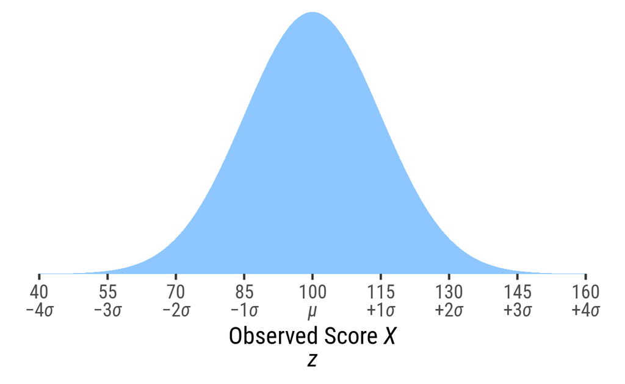

Figure 9: The main plot from Figure 8 without the annotated mathematical expression. This plot is produced using the packages ggplot2 and ggtext.

```r
ggSchneider
```

The start of the LaTeX code for the annotated expression is shown below (the full code is included in the supplementary materials for this article). The LaTeX code is arranged in three blocks: the first block of code defines some colors; the second block describes the main mathematical expression, but includes some `\eqnmark` commands to save locations within the expression; and the third block shows one of the additional mathematical expression annotations, which refers to one of the saved locations within the main mathematical expression, in this case the “z”, and positions a label relative to that location, in this case the label “z-score”, which is positioned above and to the left of the “z”.

```
\definecolor{myviolet}{HTML}{440154}
\definecolor{myblue}{HTML}{3B528B}
\definecolor{myindigo}{HTML}{21908C}
\definecolor{mygreen}{HTML}{5DC863}

\huge$
\eqnmark[myviolet]{z}{z} =
\frac{
    \eqnmark[myblue]{x}{X}-
    \eqnmark[myindigo]{mu}{\mu}}{
    \eqnmark[mygreen]{sigma}{\sigma}}
$

\annotate[
    yshift=1em,
    myviolet,
    align=right]
    {above, left}
    {z}
    {$z$-score}
```

There are several LaTeX packages required by this LaTeX code, in particular the `\eqnmark` and `\annotate` commands require the LaTeX package `annotate-equations`. As in the previous example, we can add support for this package using the `LaTeXpackage()` and `registerPackage()` functions. One difference this time is that the `annotate-equations` package is being loaded from a local `TeX` directory. The previous example relied on the LaTeX package being available as part of the user’s (or the system-wide) TeX installation.

```r
annotateEquations <-
    LaTeXpackage(name="annotate",
                 preamble="\\usepackage{TeX/annotate-equations}")
registerPackage(annotateEquations)
```

The LaTeX package `annotate-equations` is built on TikZ graphics. We do not need to load the LaTeX package `tikz` because `annotate-equations` will do that automatically. However, `xdvir` by default makes use of the bounding box information from TikZ graphics and, for images with saved locations like this, that bounding box is unreliable. The predefined support for the LaTeX package `tikz` in the `xdvir` package includes a `tikzPackage()` function that allows us to load TikZ, but ignore its bounding boxes, as shown in the following code.

```r
tikzNoBBox <-
    tikzPackage(name="tikzNoBBox", bbox=FALSE)
registerPackage(tikzNoBBox)
```

Finally, we will use the LaTeX package `roboto` to access specific variations of the Roboto font for the text labels in the annotated mathematical expressions.

```r
roboto <-
    LaTeXpackage(name="roboto",
                 preamble="\\usepackage[sfdefault,condensed]{roboto}")
registerPackage(roboto)
```

Rendering the annotated mathematical expression on the plot requires integrating the LaTeX output with the ggplot2 plot. In particular, we want to align the top of the LaTeX output with the top of the density curve and we want to align the right side of the LaTeX output with the right edge of the label “160” on the x-axis.

We saw in an earlier section how to use `element_latex()` to draw LaTeX text in labels such as the plot title on a ggplot2 plot and how to use `geom_latex()` to draw LaTeX text as data symbols. In this example, we are adding a single LaTeX annotation at a specific position within a ggplot2 plot, so we use the gggrid package (Murrell 2022). This package provides the `grid_panel()` function, which we can add to a ggplot2 plot, much like the standard `ggplot2::geom_point()` function, to add `grid` drawing to a `ggplot2` plot. The first argument to `grid_panel()` is a function that must generate a `grid` grob for ggplot2 to draw, based on the data values that ggplot2 passes to it. In this case, we define a function called `annotation()`, which calls the `xdvir` function `latexGrob()`. The `latexGrob()` function is similar to `grid.latex()` except that it creates a description of something to draw rather than immediately drawing it. We pass to `latexGrob()` the LaTeX code to draw the annotated mathematical expression (`schneiderTeX`), a set of `packages` to load, and arguments that position the output relative to the plot. The final result is shown in Figure 8.

```r
library(gggrid)

annotation <- function(data, coords) {
    latexGrob(schneiderTeX,
              packages=c("tikzNoBBox", "annotate", "roboto", "xcolor"),
              x=unit(coords$x, "npc") + 0.5*stringWidth("160"),
              y=coords$y, hjust=1, vjust=1)
}

ggSchneider +
    grid_panel(annotation,
               aes(x=x, y=y),
               data=data.frame(x=160, y=dnorm(100, mean=100, sd=15)))
```

## 12 Example 3

This section provides another demonstration of the range of possibilities that is provided by LaTeX typesetting. This time we add annotations that are formatted as numbered list items below a plot (Figure 10).

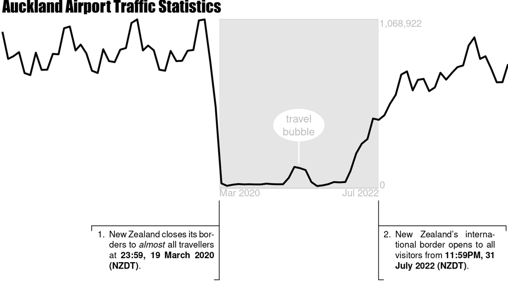

Figure 10: A plot with numbered list items as annotations below the plot. This plot is an adaptation of Figure 10 from Murrell (in press).

The main plot is a ggplot2 plot with a number of relatively simple annotations already added. The details of the code are not particularly relevant to this article, so the main plot is described in the object `ggANZJS`, which is defined in the supplementary materials for the article. One point worth noting is that the LaTeX annotations that we will be adding are required to fit within the lines that extend below the plot. In other words, we will be specifying a fixed width for the LaTeX output to fit into. The main plot produced by `ggANZJS` is shown in Figure 11.

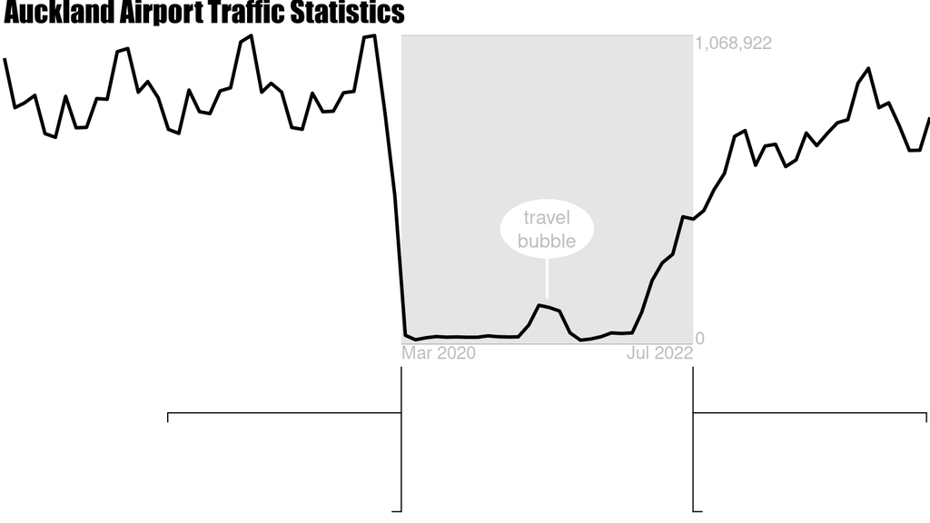

Figure 11: The main plot from Figure 10 without the numbered list items as annotations. This plot is produced using the ggplot2 package.

```r
ggANZJS
```

We will focus on drawing just the left-hand LaTeX annotation. The LaTeX code is shown below. This includes commands to control the font size and an `enumerate` environment that creates a numbered list item.

```
%
\fontsize{10}{12}
\selectfont
\begin{enumerate}
\item New Zealand closes its borders to \textit{almost} all travellers at
\textbf{23:59, 19 March 2020 (NZDT)}.
\end{enumerate}
```

As with the previous example, we have a single annotation that we want to position quite carefully, so we define a function that generates a `grid` grob to use with the `grid_panel()` function from the gggrid package. The `labelLeft()` function calls `latexGrob()`, gives it the LaTeX code to draw (`closeTeX`), specifies the position for the LaTeX output, and specifies a `width` for the output to be typeset within.

```r
labelLeft <- function(data, coords) {
    x1 <- coords$x[1]
    x2 <- coords$x[2]
    w <- unit(1 - x2, "npc") - unit(1, "mm")
    gap <- 15
    latex1 <- latexGrob(closeTeX,
                        x=unit(x1, "npc") - unit(2, "mm"),
                        y=unit(0, "npc") - unit(gap, "mm") - unit(2, "mm"),
                        hjust=1, vjust=1,
                        width=w)
}
```

The following code combines the left-hand label annotation, and a very similar right-hand label annotation, with the `ggANZJS` plot. The final result is shown in Figure 10.

```r
ggANZJS +
    grid_panel(labelLeft,
               aes(x=borders),
               data=data.frame(borders=c(borderClosed, borderOpen))) +
    grid_panel(labelRight,
               aes(x=borders),
               data=data.frame(borders=c(borderClosed, borderOpen)))
```

## 13 Example 4

This section provides an example of integrating `grid.latex()` output with a multi-panel lattice plot (Sarkar 2008). The plot is shown in Figure 12.

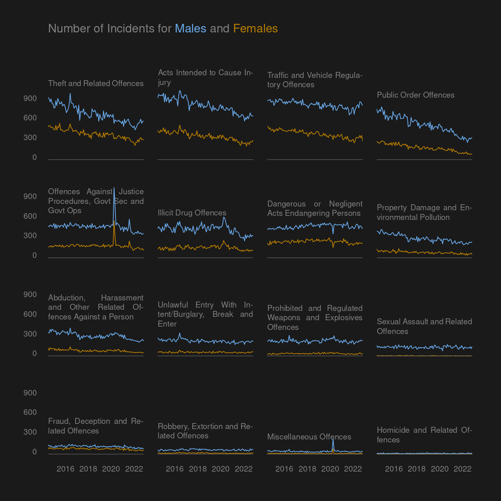

Figure 12: A lattice plot with LaTeX text used for the plot title and for annotations in each panel.

The main plot is a lattice plot consisting of multiple panels, with separate lines for males and females. The details of the code for generating the main plot are not relevant to this article, so it is described in the object `latticeCrime`, which is defined in the supplementary material. The main plot produced by `latticeCrime` is shown in Figure 13.

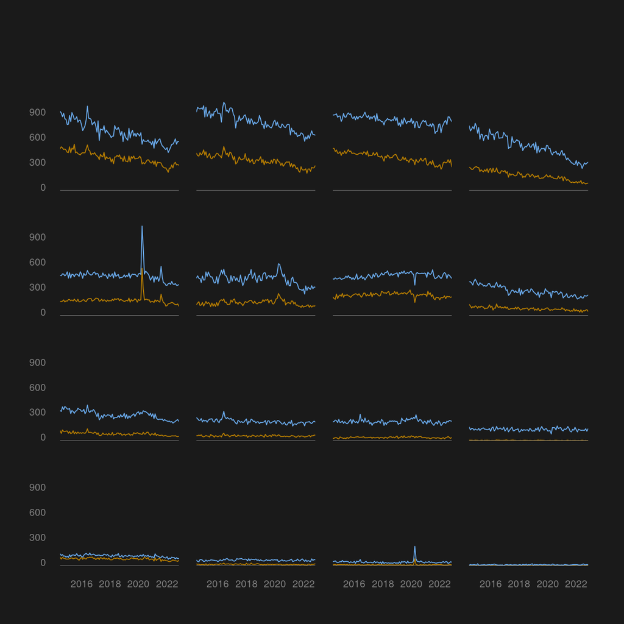

Figure 13: The main plot from Figure 12 without the title and annotations in each panel. This plot is produced using the lattice package.

```r
latticeCrime
```

We can add drawing to each panel of a lattice plot by providing a *panel function*. The panel function is passed the relevant data for the panel, and the code within the panel function is run in the panel viewport, which means that the appropriate axis scales are available. This means that we can include a call to `grid.latex()` within a panel function in order to add LaTeX text to each panel. For example, the following code defines the panel function for Figure 12. This function calculates the appropriate label for the panel and encloses that within a LaTeX `minipage` environment that is the width of the panel. This means that the label is typeset to be fully-justified within the panel (unless it is a single line that is narrower than the panel). We use a `minipage` environment in the LaTeX fragment rather than just using the `width` argument to `grid.latex()` because `minipage` produces a more precise width. The panel function then calls `grid.latex()` to draw that LaTeX fragment, placing the label slightly above the first data value for males. The call to the `mainPanel()` function draws the yellow and blue lines that are part of the main plot.

```r
latexPanel <- function(x, y, subscripts, groups, ...) {
    type <- crime$Type[subscripts][1]
    labelY <- y[groups == "Male"][1]
    labelWidth <- convertWidth(unit(1, "npc"), "in", valueOnly=TRUE)
    panelTeX <- paste0("\\begin{minipage}{", labelWidth, "in}",
                       type,
                       "\\end{minipage}")
    grid.latex(panelTeX,
               x=0, hjust="left",
               y=unit(labelY, "native") + unit(4, "mm"), vjust="bottom",
               gp=gpar(col=lightGrey, fontsize=8))
    mainPanel(x, y, subscripts, groups, ...)
}
```

The title of a lattice plot can be specified as a `grid` grob. This means that we can call `latexGrob()` to generate a title for the plot in Figure 12. The LaTeX fragment below describes the label, first defining three colors, and then giving the title text, with the words “Male” and “Female” colored differently.

```r
titleTeX <- r"(%
\definecolor{lightGrey}{RGB}{128,128,128}
\definecolor{lattice1}{RGB}{105,169,234}
\definecolor{lattice2}{RGB}{181,124,1}
\color{lightGrey}
Number of Incidents for \textcolor{lattice1}{Males} and
\textcolor{lattice2}{Females}
)"
```

The following code calls `latexGrob()` to define the title. We pass the LaTeX fragment `titleTeX`, we position the title to line up with the left edge of the first column of panels, and we load the LaTeX package `xcolor` so that the colors work.

```r
latexTitle <- latexGrob(titleTeX, x=titleX, hjust="left",
                        packages="xcolor")
```

The following code creates the final plot by adding the panel function `latexPanel` and the title `latexTitle` to the main plot `latticeCrime`. The final result is shown in Figure 12.

```r
update(latticeCrime,
       panel=latexPanel,
       main=latexTitle)
```

## 14 Discussion

The `xdvir` package provides convenient high-level functions for rendering LaTeX fragments as labels, annotations, or data symbols on R plots. The package also provides lower-level functions that allow more fine control over the authoring, typesetting, and rendering of LaTeX code in R.

The benefit of the `xdvir` package is access to the typesetting capabilities of LaTeX. This ranges from relatively simple features like changes in font family, font weight, and font style, and automatic line breaks, to intermediate features like full justification, hyphenation, and high-quality mathematical expressions, and more advanced features like enumerated lists, multiple columns, and TikZ graphics.

One limitation of the `xdvir` package is that rendering LaTeX fragments is noticeably slower than rendering simple character values. This is mainly because the typesetting step requires running a TeX engine to produce a DVI file. The `xdvir` package performs some caching in order to minimize the problem, but the time cost can still be quite large. For example, Figure 12 requires running a TeX engine 17 times.

Another limitation of the `xdvir` package is that it requires a graphics device that can render typeset glyphs. This currently includes the `pdf()` and `quartz()` devices, plus all devices based on the Cairo graphics library (Packard et al. 2025), and graphics devices provided by the `ragg` package (Pedersen and Shemanarev 2024).

A final major limitation of `xdvir` is that it only currently supports two TeX engines: XeTeX and recent LuaTeX. The function `TeXstatus()` can be used to report on whether these are available. An implicit limitation is that `xdvir` requires a TeX installation, though that is simplified through a dependency on the tinytex package (Xie 2024).

Given these limitations, it is worth discussing alternative approaches. The first section of this article mentioned gridtext, ggtext, and marquee. These packages provide alternative ways to render non-trivial text labels, but do so through Markdown and/or HTML rather than LaTeX. Although they may not be able to produce as wide a range of results compared to LaTeX code, they will perform much faster and require fewer dependencies than `xdvir`. There are also a number of packages that perform specific text-placement tasks, for example geomtextpath (Cameron and van den Brand 2025), which can arrange text along an arbitrary path, and directlabels (Hocking 2024) and ggforce (Pedersen 2024), which provide functions for cleverly positioning text annotations, though without typesetting facilities. The advantage of `xdvir` by comparison with these packages is that it is possible to produce more advanced typesetting results thanks to having access to LaTeX.

The tikzDevice package (Sharpsteen and Bracken 2023) is an interesting alternative because, where `xdvir` integrates LaTeX text with R graphics, tikzDevice reverses the process and integrates R graphics with LaTeX. The tikzDevice package provides an R graphics device that converts R plots into TikZ pictures so that R plots can include labels with LaTeX fragments and R plots can be deeply integrated with LaTeX documents. There is also a ggtikz package (Thomas 2024) that builds on tikzDevice to allow TikZ annotations on ggplot2 plots. The main difference compared to `xdvir` is the destination: if we use `xdvir`, we end up with LaTeX output within an R plot; if we use tikzDevice or ggtikz, we end up with an R plot within LaTeX output. If the final destination is a LaTeX document, then tikzDevice or ggtikz may provide more convenience and greater control. However, if the final destination is more general, or unknown, then `xdvir` may be the more appropriate solution.

The latex2exp package (Meschiari 2022) is another package that works in the opposite direction to `xdvir`. This package takes a LaTeX fragment and converts it to an R *plotmath* expression. This allows users familiar with LaTeX to access R’s math-drawing facility whereas `xdvir` allows users to access LaTeX’s math-drawing facility, which is far superior. The advantage of latex2exp, as with many of these alternative approaches, is that it does not have any system dependencies, whereas `xdvir` requires a TeX installation.

Another alternative approach to including LaTeX output in R plots is to import an image of the LaTeX output. This approach harks back to early solutions for including LaTeX mathematical expressions in web pages by generating PNG images from LaTeX fragments. However, more modern technologies, such as SVG, mean that this approach can yield a much higher-quality result, as demonstrated by Schneider (2023). One simple advantage of the `xdvir` approach is the level of convenience that it provides by automating the authoring and typesetting steps. The `xdvir` package also provides more possibilities to integrate LaTeX output with other drawing in R through anchors and saved positions.

Some of the limitations of `xdvir` may also be overcome by further development. For example, it may be possible to extend support to more TeX engines and to more graphics devices. Providing support for more LaTeX packages is another area for future work.

## 15 Acknowledgments

The `xdvir` package depends on Yihui Xie’s tinytex package for the typesetting step. This package makes it much simpler to make use of TeX engines, including performing multiple runs when necessary, and much easier to install LaTeX packages (and TeX itself).

Claus O. Wilke’s ggtext package and Thomas Lin Pedersen’s marquee package provided excellent templates for the integration of improved text-drawing facilities with ggplot2.

The author owes a debt of gratitude to Marc-Olivier Beausoleil (Figure 1), Thomas Rahlf (Figure 6), and Joel Schneider (Figure 8) for sharing their work and for giving either implicit or explicit permission to base several of the examples in this article on their work.

Finally, thanks to the journal editor and an anonymous reviewer who provided many helpful criticisms and suggestions that helped to improve both the package and this article.

### 15.1 CRAN packages used

ggtext, gridtext, marquee, ggplot2, xtable, latexpdf, rmarkdown, texPreview, gridGraphics, gggrid, lattice, tinytex, geomtextpath, directlabels, ggforce, tikzDevice, ggtikz, latex2exp

### 15.2 CRAN Task Views implied by cited packages

ChemPhys, NetworkAnalysis, Phylogenetics, ReproducibleResearch, Spatial, TeachingStatistics

T. Bergsma. *Latexpdf: Convert tables to PDF or PNG.* 2023. URL https://CRAN.R-project.org/package=latexpdf. R package version 0.1.8.

M. A. Borkin, Z. Bylinskii, N. W. Kim, C. M. Bainbridge, C. S. Yeh, D. Borkin, H. Pfister and A. Oliva. Beyond memorability: Visualization recognition and recall. *IEEE Transactions on Visualization and Computer Graphics*, 22(1): 519–528, 2016. DOI 10.1109/TVCG.2015.2467732.

A. Cameron and T. van den Brand. *geomtextpath: Curved text in ’ggplot2’.* 2025. URL https://CRAN.R-project.org/package=geomtextpath. R package version 0.1.5.

D. B. Dahl, D. Scott, C. Roosen, A. Magnusson and J. Swinton. *xtable: Export tables to LaTeX or HTML.* 2019. URL https://CRAN.R-project.org/package=xtable. R package version 1.8-4.

M. A. Hearst. Show it or tell it? Text, visualization, and their combination. *Commun. ACM*, 66(10): 68–75, 2023. URL https://doi.org/10.1145/3593580.

T. D. Hocking. *directlabels: Direct labels for multicolor plots.* 2024. URL https://CRAN.R-project.org/package=directlabels. R package version 2024.1.21.

H.-K. Kong, Z. Liu and K. Karahalios. Frames and slants in titles of visualizations on controversial topics. In *Proceedings of the 2018 CHI conference on human factors in computing systems*, pages. 1–12 2018. New York, NY, USA: Association for Computing Machinery. ISBN 9781450356206. URL https://doi.org/10.1145/3173574.3174012.

S. Meschiari. *latex2exp: Use LaTeX expressions in plots.* 2022. URL https://CRAN.R-project.org/package=latex2exp. R package version 0.9.6.

P. Murrell. *gggrid: Draw with ’grid’ in ’ggplot2’.* 2022. URL https://CRAN.R-project.org/package=gggrid. R package version 0.2-0.

P. Murrell. Text in R graphics. *Australian & New Zealand Journal of Statistics*, in press. URL https://onlinelibrary.wiley.com/doi/abs/10.1111/anzs.12438.

P. Murrell. The gridGraphics package. *The R Journal*, 7: 151–162, 2015. URL https://rjournal.github.io/.

P. Murrell and R. Ihaka. An approach to providing mathematical annotation in plots. *Journal of Computational and Graphical Statistics*, 9(3): 582–599, 2000. URL https://www.tandfonline.com/doi/abs/10.1080/10618600.2000.10474900.

P. Murrell, T. L. Pedersen and S. Urbanek. Rendering typeset glyphs in R graphics. 2023-01. Department of Statistics, The University of Auckland. 2023. URL https://stattech.blogs.auckland.ac.nz/2023/05/06/2023-01-rendering-typeset-glyphs-in-r-graphics. version 1.

P. Murrell and Z. Wen. *gridGraphics: Redraw base graphics using ’grid’ graphics.* 2020. URL https://CRAN.R-project.org/package=gridGraphics. R package version 0.5-1.

K. Packard, C. Worth and B. Esfahbod. Cairo graphics library. 2025. URL https://www.cairographics.org/. Accessed: 2025-01-20.

T. L. Pedersen. *ggforce: Accelerating ’ggplot2’.* 2024. URL https://CRAN.R-project.org/package=ggforce. R package version 0.4.2.

T. L. Pedersen and M. Mitáš. *marquee: Markdown parser and renderer for R graphics.* 2024. URL https://CRAN.R-project.org/package=marquee. R package version 0.1.0.

T. L. Pedersen and M. Shemanarev. *ragg: Graphic devices based on AGG.* 2024. URL https://CRAN.R-project.org/package=ragg. R package version 1.3.3.

T. Rahlf. *Data visualisation with R: 100 examples.* 1st ed Springer Publishing Company, Incorporated, 2017. URL https://link.springer.com/book/10.1007/978-3-030-28444-2.

D. Sarkar. *Lattice: Multivariate data visualization with R.* New York: Springer, 2008. URL http://lmdvr.r-forge.r-project.org.

W. J. Schneider. Annotated Equations in ggplot2. 2023. URL https://wjschne.github.io/posts/2023-07-23-latex-equation-in-ggplot2/.

C. Sharpsteen and C. Bracken. *tikzDevice: R graphics output in LaTeX format.* 2023. URL https://CRAN.R-project.org/package=tikzDevice. R package version 0.12.6.

J. Sidi and D. Polhamus. *texPreview: Compile and preview snippets of ’LaTeX’.* 2024. URL https://CRAN.R-project.org/package=texPreview. R package version 2.1.0.

O. Thomas. *Ggtikz: Post-process ’ggplot2’ plots with ’TikZ’ code using plot coordinates.* 2024. URL https://CRAN.R-project.org/package=ggtikz. R package version 0.1.3.

H. Wickham. *ggplot2: Elegant graphics for data analysis.* Springer-Verlag New York, 2016. URL https://ggplot2.tidyverse.org.

C. O. Wilke and B. M. Wiernik. *ggtext: Improved text rendering support for ’ggplot2’.* 2022a. URL https://CRAN.R-project.org/package=ggtext. R package version 0.1.2.

C. O. Wilke and B. M. Wiernik. *gridtext: Improved text rendering support for ’grid’ graphics.* 2022b. URL https://CRAN.R-project.org/package=gridtext. R package version 0.1.5.

Y. Xie. *tinytex: Helper functions to install and maintain TeX Live, and compile LaTeX documents.* 2024. URL https://github.com/rstudio/tinytex. R package version 0.54.

Y. Xie, J. J. Allaire and G. Grolemund. *R markdown: The definitive guide.* Boca Raton, Florida: Chapman; Hall/CRC, 2018. URL https://bookdown.org/yihui/rmarkdown.